# Geospatial risk modeling - the case of crime

Ken Steif, PhD

October 27, 2019

# 1.1 Predictive Policing & geospatial risk models

Of the many public sector machine learning algorithms that you may have heard of, none garner more ire than the use case we’ll develop in this chapter - Predictive policing. Predictive Policing is a form of geospatial risk prediction that borrows the locational experience of crimes observed in the recent past and tests the extent to which those experiences generalize to places that may be at risk for crime despite a lack of reporting.

Law enforcement has significant resource allocation questions. In 2017, the Chicago Police Department recorded 268,387 incidents, which equates to 735 incidents per day on average. There is a clear need for an operational planning tool aimed at reducitng crime. Victims of crime and even those who live in fear of crime, incur real costs, physically, emotionally and financially. Crime can depress land values and hinder economic development. Crime can deter children from walking to school in the morning or families from enjoying an evening on their porch. Crime can be both the cause and the symptom of many significant socio-emotional and economic outcomes.

With so much data, one might think predictive policing would be a public sector data scientist’s dream. In reality, most of these datasets are so biased that without an intense focus on model validation, most law enforcement use cases of predictive policing are unuseful. A useful predictive policing model is one which can predict *explicit* crime risk by way of meaningful risk factors without being biased by the *implicit* risk generated from biased policing interventions.

Let’s unpack this a bit. As we’ll learn below, these algorithms predict risk by regressing a crime outcome like burglary on built environment risk factors like blight. It may be that neighborhoods with certain environmental risk factors breed the behavior that leads to increasead crime. It may also be that people with a high propensity to commit crime **or report it**, select into high crime neighborhoods. This idea is called ‘selection bias’, and it is the most difficult hurdle to overcome in any social science research.

Selection bias is discussed far more often in the context of inferential statistics than in predictive modeling. What is the effect of good teachers on educational outcomes? What is the effect of college on future wages? What is the effect of crime on home prices? All of these questions suffer from selection bias. Parents select into certain school districts and schools conditional on their preference for education quality. Students select into college conditional on their education background and willingenss to pay. Criminals choose to pray on certain neighborroods based on their preception of risk and reward.

In other words, none of this selection happens at random and if the selection criteria goes unaccounted for in the model, it will fall into the error term. Let’s imagine that the unobserved selection criteria is the sytsematic over-policing of minority neighborhoods by police. Although a white and non-white neighborhood may share the same explict risk factors, such as blight, the non-white neighborhood may have more reported crimes due to the ‘reporting bias’ of police. In this chapter, burglary risk is predicted. The assumption is that there is less reporting bias in burglary relative to other crime types like drug crime, for instance. The hypothesis underlying the model is that risk is a function of *exposure* to environmental risk and protective factors. Blight and vacancy are often strong risk factors for crime. Churches, recreation centers and other community assets may be examples of factors that help communities project against crime. There is an important literature on the Broken Windows Theory that I need to add later.

## 1.2 On the accuracy/generalizability tradeoff in geospatial risk prediction models

The principal motivation for geospatial risk prediction is the idea of ‘latent risk’. Crime is a relatively rare event and it may be happening at a greater rate than what is observe in the data. The goal of the model then, is to predict this latent risk by borrowing the experience of observed crimes and testing how well those experiences generalize to places where no crime has been observed. Assuming these predictions are ‘useful’, defined as generalizable across different community contexts, it may be possible to create a tool that Police can use to more efficiently allocate their limited resources across space.

Accuracy & generalizability is far more nuanced in this context relative to say home price or churn prediction. A model that is perfectly accurate is one where the predicted crime count equals the observed crime count and such a model would fail to identify areas at latent risk. This makes goodness of fit is very difficult to judge for geospatial risk prediction models. The goal is to achieve a useful accuracy that improves on the resource allocation better than the business as usual approach, while ensuring this accuracy generalizes appropriately.

This chapter is organized as follows. In the next section, a host of crime, risk and protective factor data is downloaded and wrangled directly from the Chicago Open Data website. Section 3 focuses on featuring engineering. Section 4 develops some new spatial structure features. Section 5 estimates and maps risk predictions, and Section 6 validates those predictions for accuracy and generalizability. **Section 7 outlines the homework for this assignment**.

## 1.2 Setup

Begin by loading the requisite packages and create a `mapTheme()` function that is used to standardized the map outputs created below.

```r
library(tidyverse)
library(sf)
library(QuantPsyc)
library(RSocrata)
library(viridis)
library(caret)
library(spatstat)
library(spdep)
library(FNN)
library(grid)
library(gridExtra)
library(knitr)
library(kableExtra)
library(tidycensus)

mapTheme <- function(base_size = 12) {
  theme(
    text = element_text( color = "black"),
    plot.title = element_text(size = 14,colour = "black"),
    plot.subtitle=element_text(face="italic"),
    plot.caption=element_text(hjust=0),
    axis.ticks = element_blank(),
    panel.background = element_blank(),axis.title = element_blank(),
    axis.text = element_blank(),
    axis.title.x = element_blank(),
    axis.title.y = element_blank(),
    panel.grid.minor = element_blank(),
    panel.border = element_rect(colour = "black", fill=NA, size=2)
  )
}
```

# 2.1 Data wrangling: Creating the `fishnet`

What is the appropriate unit of analysis for predicting crime risk? The answer to this question brings about a whole new set of scale problems. In the home price use case, the house was the obvious unit of analysis, because features internal to the home play an important role. Crime events like assault or burglary do not come with similar information - all we know is that a crime event happened here.

At what spatial unit then, is it sensible to predict crime? The first part of the answer should be informed by the resource allocation process. Many police departments divide the city into administrative areas to which centralized resources are provided but some measure of autonomy is allowed. How useful would a patrol allocation algorithm be with a single prediction for each Police Beat or District?

There are thousands of people living in the average Police Beat and tens or hundreds of thousands of people living in a single Police District. It’s doubtful that these areas would provide enough precision intelligence on where to patrol. Predicting crime across these discrete administrative units may also assume for instance, that crime risk varies significantly on either immediate side of two adjacent administrative areas, a clear instance of the MAUP.

In the code below, `policeDistricts` and `policeBeats` are downloaded and mapped.

```r
policeDistricts <-
  st_read("https://data.cityofchicago.org/api/geospatial/fthy-xz3r?method=export&format=GeoJSON") %>%
  st_transform(crs=102271) %>%
  dplyr::select(District = dist_num)

policeBeats <-
  st_read("https://data.cityofchicago.org/api/geospatial/aerh-rz74?method=export&format=GeoJSON") %>%
  st_transform(crs=102271) %>%
  dplyr::select(District = beat_num)

bothPoliceUnits <- rbind(mutate(policeDistricts, Legend = "Police Districts"),
                         mutate(policeBeats, Legend = "Police Beats"))
```

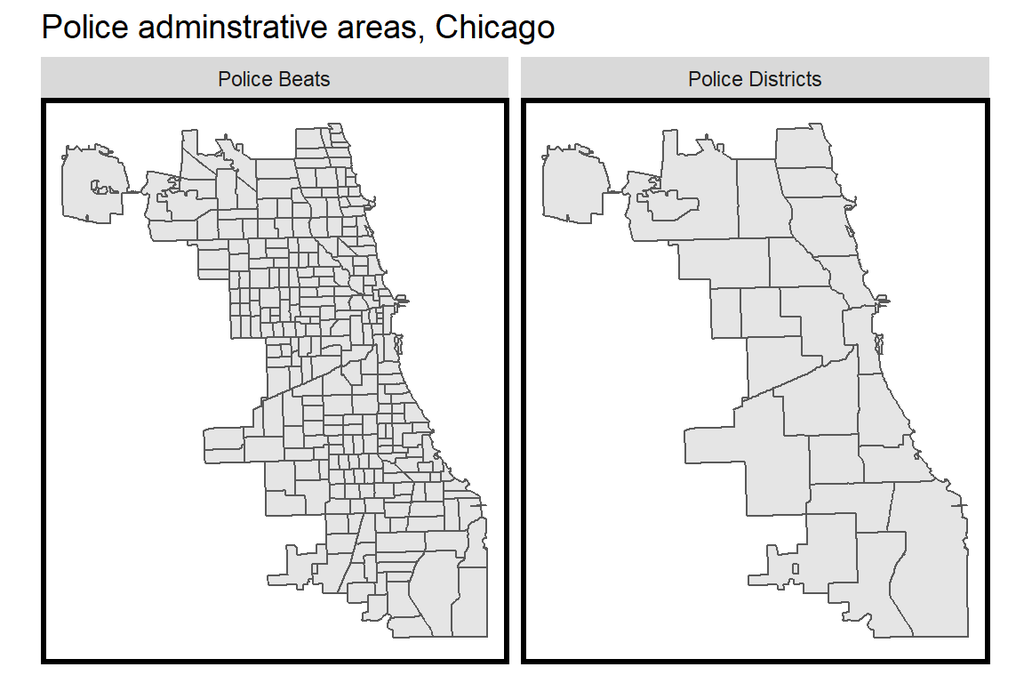

```r
ggplot() +
  geom_sf(data = bothPoliceUnits) +
  facet_wrap(~Legend) +
  labs(title = "Police adminstrative areas, Chicago") +
  mapTheme()
```

Instead of thinking about crime risk as a phenomena that varies across administrative units, think of it as one that varies smoothly across space - similar to elevation. As we’ll discover, crime is clustered, and thus crime in one location is likely correlated with crime nearby. One might then assume that crime risk dissipates outward from concentrated crime hot spots much like how elevation ebbs and flows from mountain tops to valleys. The best way to represent such a smooth spatial surface is to aggregate point phenomena to a lattice of grid cells. The reader familiar with GIS will immediate recognize that this tends to be done with ‘Raster’-based techniques. For this exercise, our grid cells will be vector polygons.

```r
chicagoBoundary <-
  st_read("C:/Users/kennethsteif/Desktop/spring_2017/theBook/riskPredictionChapter/chicago_Boundary.shp") %>%
  st_transform(crs=102271)
fishnet <-
  st_make_grid(chicagoBoundary, cellsize = 500) %>%
  st_sf()
```

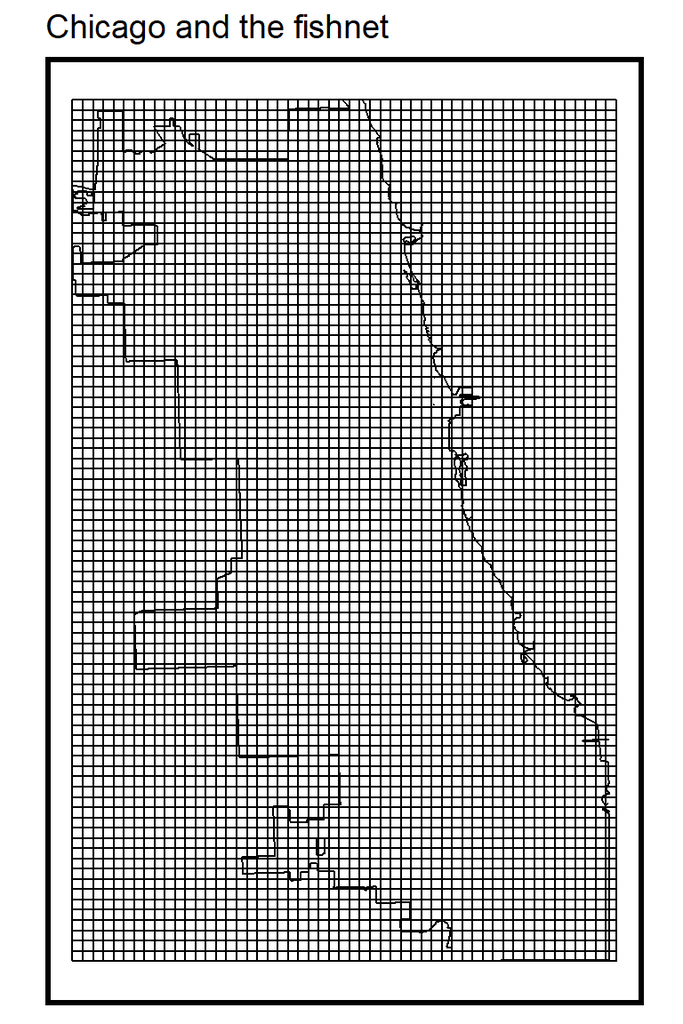

```r
ggplot() +
  geom_sf(data=chicagoBoundary, fill=NA, colour="black") +
  geom_sf(data=fishnet, fill=NA, colour="black") +
  labs(title = "Chicago and the fishnet") +
  mapTheme()
```

All the extra grid cells outside of Chicago are not needed. Below a spatial subset is used to select only the grid cells that fall into `chicagoBoundary`. A grid cell specific `uniqueID` is also `mutate` which can be used for joining purposes later.

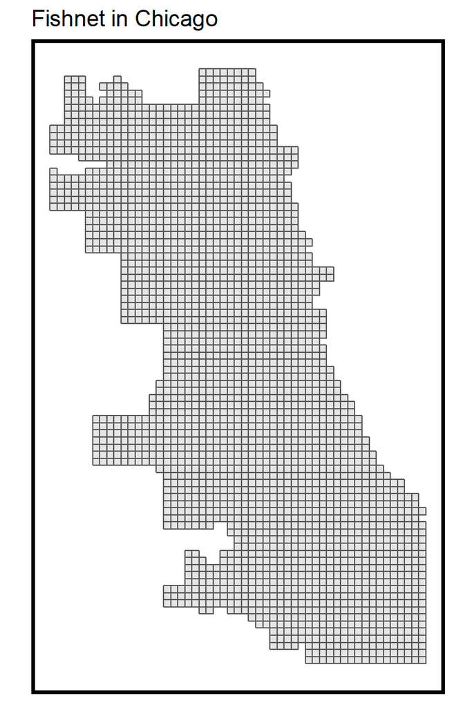

```r
fishnet <-
  fishnet[chicagoBoundary,] %>%
  mutate(uniqueID = rownames(.)) %>%
  dplyr::select(uniqueID)

ggplot() +
  geom_sf(data=fishnet) +
  labs(title = "Fishnet in Chicago") +
  mapTheme()
```

Next, some `burglaries` are downloaded from the Chicago Open Data site using the `RSocrata` package. Socrata is the creator of the open source platform that Chicago uses to share data. This package provides a quick way to query and download from the Socrata API. We begin with the dependent variables, burglaries in 2017.

The codeblock below downloads the data and selects only those burglaries that are “forcible entry”. Some additional data wrangling is accomplished first by removing extraneous characters from the `Location` field with `gsub`. The resulting field is then converted to `seperate` fields of `X` and `Y` coordinates. Those fields are then made numeric, converted to simple features, projected, and duplicate geometries are removed with `distinct`.

```r
burglaries <-
  read.socrata("https://data.cityofchicago.org/Public-Safety/Crimes-2017/d62x-nvdr") %>%
  filter(Primary.Type == "BURGLARY" &
         Description == "FORCIBLE ENTRY") %>%
  mutate(x = gsub("[()]", "", Location)) %>%
  separate(x,into= c("Y","X"), sep=",") %>%
  mutate(X = as.numeric(X),
         Y = as.numeric(Y)) %>%
  na.omit %>%
  st_as_sf(coords = c("X", "Y"), crs = 4326, agr = "constant")%>%
  st_transform(102271) %>%
  distinct()

burglaries
```

```
## Simple feature collection with 6874 features and 0 fields
## geometry type:  POINT
## dimension:      XY
## bbox:           xmin: 340491.5 ymin: 552960.4 xmax: 367153.1 ymax: 594816
## epsg (SRID):    102271
## proj4string:    +proj=tmerc +lat_0=36.66666666666666 +lon_0=-88.33333333333333 +k=0.9999749999999999 +x_0=300000 +y_0=0 +ellps=GRS80 +towgs84=0,0,0,0,0,0,0 +units=m +no_defs
## First 10 features:
##                     geometry
## 1  POINT (351792.3 588848.3)
## 2  POINT (347350.2 580583.9)
## 3  POINT (353067.6 568909.1)
## 4  POINT (358621.1 566842.6)
## 5  POINT (356256.4 566962.4)
## 6  POINT (350707.8 587808.9)
## 7  POINT (357298.6 565776.1)
## 8  POINT (357303.7 569488.2)
## 9  POINT (353526.9 584898.7)
## 10 POINT (363978.3 565987.6)
```

Next, the burglaries throughout Chicago are mapped as points.

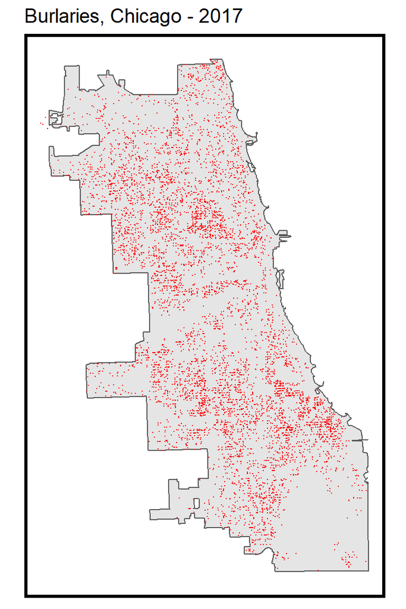

```r
ggplot() +
  geom_sf(data = chicagoBoundary) +
  geom_sf(data = burglaries, colour="red", size=0.1, show.legend = "point") +
  labs(title= "Burlaries, Chicago - 2017") +
  mapTheme()
```

## 2.2 Data wrangling: Joining burglaries to the `fishnet`

```r
crime_net <-
  burglaries %>%
  dplyr::select() %>%
  mutate(countBurglaries = 1) %>%
  aggregate(., fishnet, sum) %>%
  mutate(countBurglaries = ifelse(is.na(countBurglaries), 0, countBurglaries),
         uniqueID = rownames(.),
         cvID = sample(round(nrow(fishnet) / 24), size=nrow(fishnet), replace = TRUE))
```

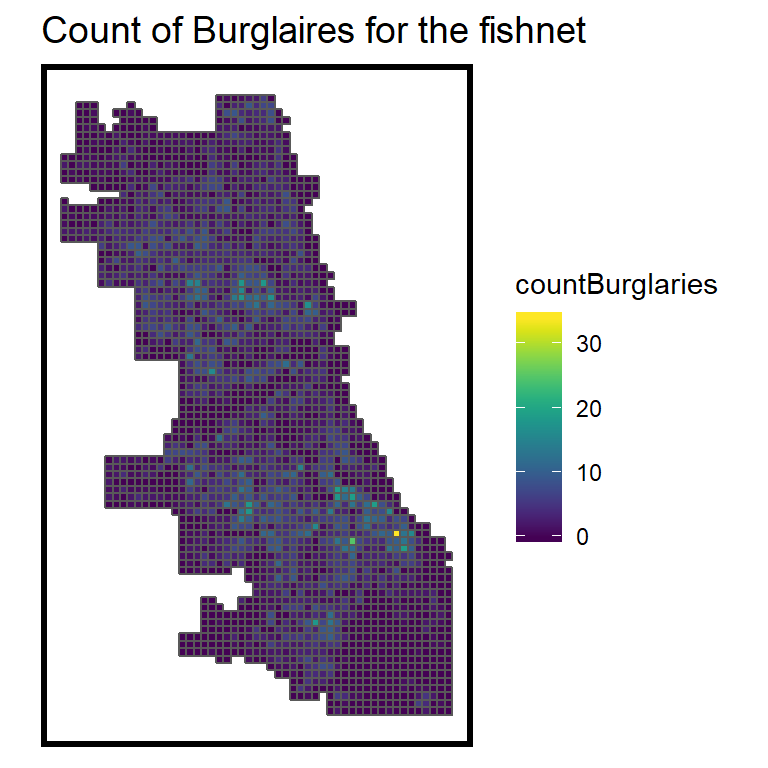

```r
ggplot() +
  geom_sf(data = crime_net, aes(fill = countBurglaries)) +
  scale_fill_viridis() +
  labs(title = "Count of Burglaires for the fishnet") +
  mapTheme()
```

## 2.3 Data wrangling risk factors

Now that the `crime_net` includes data on our dependent variable, burglary, the next step is download and wrangle a small set of risk factor features. We create a very simply model here, gathering a small number of features that help test the hypothesis that crime presence is a function of exposure to certain environmental characteristics. A typical analysis would likely require many more features.

Six risk factors are downloaded along with a neighborhood polygon layer. The data includes 311 calls for abandoned cars, street lights out, graffiti remediation, sanitation complaints and abandon buildings; as well as the location of retail stores that sell liquor to go.

Take note of the approach used to wrangle each dataset. Data is downloaded; year and coordinates are created and the latter converted to `sf`. The data is then projected and a `Legend` field is added that describes the risk factor. This allows them to be `rbind` into one dataset below to easily create small multiple maps.

```r
abandonCars <-
  read.socrata("https://data.cityofchicago.org/Service-Requests/311-Service-Requests-Abandoned-Vehicles/3c9v-pnva") %>%
  mutate(year = substr(creation_date,1,4)) %>%
  filter(year == "2017") %>%
  dplyr::select(Y = latitude, X = longitude) %>%
  na.omit() %>%
  st_as_sf(coords = c("X", "Y"), crs = 4326, agr = "constant") %>%
  st_transform(st_crs(fishnet)) %>%
  mutate(Legend = "Abandoned_Cars")

abandonBuildings <-
  read.socrata("https://data.cityofchicago.org/Service-Requests/311-Service-Requests-Vacant-and-Abandoned-Building/7nii-7srd") %>%
    mutate(year = substr(date_service_request_was_received,1,4)) %>%
    filter(year == "2017") %>%
    dplyr::select(Y = latitude, X = longitude) %>%
  na.omit() %>%
  st_as_sf(coords = c("X", "Y"), crs = 4326, agr = "constant") %>%
  st_transform(st_crs(fishnet)) %>%
  mutate(Legend = "Abandoned_Buildings")

graffiti <-
  read.socrata("https://data.cityofchicago.org/Service-Requests/311-Service-Requests-Graffiti-Removal-Historical/hec5-y4x5") %>%
    mutate(year = substr(creation_date,1,4)) %>%
    filter(year == "2017") %>%
    filter(where_is_the_graffiti_located_ == "Front" |
           where_is_the_graffiti_located_ == "Rear" | where_is_the_graffiti_located_ == "Side") %>%
    dplyr::select(Y = latitude, X = longitude) %>%
  na.omit() %>%
  st_as_sf(coords = c("X", "Y"), crs = 4326, agr = "constant") %>%
  st_transform(st_crs(fishnet)) %>%
  mutate(Legend = "Graffiti")

streetLightsOut <-
  read.socrata("https://data.cityofchicago.org/Service-Requests/311-Service-Requests-Street-Lights-All-Out/zuxi-7xem") %>%
    mutate(year = substr(creation_date,1,4)) %>%
    filter(year == "2017") %>%
    dplyr::select(Y = latitude, X = longitude) %>%
  na.omit() %>%
  st_as_sf(coords = c("X", "Y"), crs = 4326, agr = "constant") %>%
  st_transform(st_crs(fishnet)) %>%
  mutate(Legend = "Street_Lights_Out")

sanitation <-
  read.socrata("https://data.cityofchicago.org/Service-Requests/311-Service-Requests-Sanitation-Code-Complaints-Hi/me59-5fac") %>%
    mutate(year = substr(creation_date,1,4)) %>%
    filter(year == "2017") %>%
    dplyr::select(Y = latitude, X = longitude) %>%
  na.omit() %>%
  st_as_sf(coords = c("X", "Y"), crs = 4326, agr = "constant") %>%
  st_transform(st_crs(fishnet)) %>%
  mutate(Legend = "Sanitation")

liquorRetail <-
  read.socrata("https://data.cityofchicago.org/Community-Economic-Development/Business-Licenses-Cur   rent-Liquor-and-Public-Places/nrmj-3kcf") %>%
  filter(BUSINESS.ACTIVITY == "Retail Sales of Packaged Liquor") %>%
  dplyr::select(Y = LATITUDE, X = LONGITUDE) %>%
  na.omit() %>%
  st_as_sf(coords = c("X", "Y"), crs = 4326, agr = "constant") %>%
  st_transform(st_crs(fishnet)) %>%
  mutate(Legend = "Liquor_Retail")

neighborhoods <-
  st_read("https://raw.githubusercontent.com/blackmad/neighborhoods/master/chicago.geojson") %>%
  st_transform(st_crs(fishnet))
```

Next, a small multiple map of the each of these risk factors is plotted below as points.

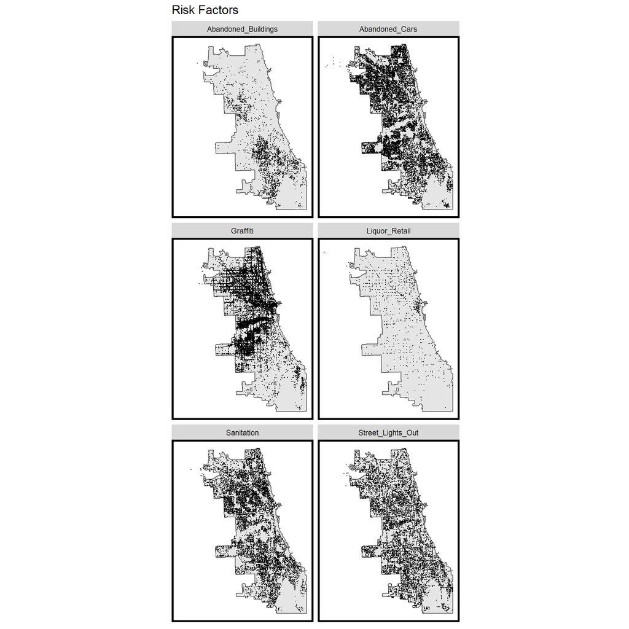

```r
ggplot() +
  geom_sf(data=chicagoBoundary) +
  geom_sf(data = rbind(abandonCars,streetLightsOut,abandonBuildings,
                      liquorRetail, graffiti, sanitation),
         size = .1) +
  facet_wrap(~Legend, ncol = 2) +
  labs(title = "Risk Factors") +
  mapTheme()
```

# 3.1 Feature engineering - Count of features by grid cell

There are many ways to engineer features that test the exposure hypothesis. In this chapter, two such approaches are demonstrated. The first simply sums the number of a given risk factor points occuring in a given grid cell. This is done by binding together the individual risk factor layers; then spatial joining (`st_join`) *the fishnet to each point*. The outcome is a large point layer with a column for each fishnet `uniqueID`. The layer is then converted to a data frame with `st_set_geometry`.

The next step is to move from a long form layer of risk factor points with grid cell `uniqueID`s, to a wide form layer of grid cells with risk factor columns. Note the results of grouping by grid cell `uniqueID` and risk factor `Legend`, then counting the number of points. The `full_join` adds the fishnet geometries and `spread` converts to wide form. The output, `vars_net` is useful for regression purposes.

This is fairly complex data wrangling strategy, and it will be helpful for you to run each line separately.

```r
vars_net <-
  rbind(abandonCars,streetLightsOut,abandonBuildings,
        liquorRetail, graffiti, sanitation) %>%
  st_join(., fishnet, join=st_within) %>%
  st_set_geometry(NULL) %>%
  group_by(uniqueID, Legend) %>%
  summarize(count = n()) %>%
  full_join(fishnet) %>%
  spread(Legend, count, fill=0) %>%
  st_sf() %>%
  dplyr::select(-`<NA>`) %>%
  na.omit()

vars_net
```

```
## Simple feature collection with 2458 features and 7 fields
## geometry type:  POLYGON
## dimension:      XY
## bbox:           xmin: 341164.1 ymin: 552875.4 xmax: 367664.1 ymax: 594875.4
## epsg (SRID):    102271
## proj4string:    +proj=tmerc +lat_0=36.66666666666666 +lon_0=-88.33333333333333 +k=0.9999749999999999 +x_0=300000 +y_0=0 +ellps=GRS80 +towgs84=0,0,0,0,0,0,0 +units=m +no_defs
## # A tibble: 2,458 x 8
## # Groups:   uniqueID [2,458]
##    uniqueID Abandoned_Build~ Abandoned_Cars Graffiti Liquor_Retail
##    <chr>               <dbl>          <dbl>    <dbl>         <dbl>
##  1 1                       0              0        0             0
##  2 10                      0              0        0             0
##  3 100                     0              4        1             0
##  4 1000                    1              4        0             0
##  5 1001                    0              3        1             0
##  6 1002                    0              6        1             0
##  7 1003                    0              5        2             0
##  8 1004                    0              1        0             0
##  9 1005                    0              0        0             0
## 10 1006                    0              0        0             0
## # ... with 2,448 more rows, and 3 more variables: Sanitation <dbl>,
## #   Street_Lights_Out <dbl>, geometry <POLYGON [m]>
```

Now let’s map each count feature as part of a small multiple map. Note that each risk factor in `vars_net` has a different range (min, max). A normal `ggplot` would allow us to `facet_wrap(~group, scales = "free")` to create ‘free’ scales for each map. At this time, such functionality has not been ported to `geom_sf`. Instead, a function is used to loop through the creation of individual risk factor maps and compile (ie. `grid.arrange`) them into one small multiple plot.

`vars_net.long` is `vars_net` in long form. `vars` is vector of `Variable` names and `mapList` is an empty list. The loop says for for each `Variable`, *i*, in `vars`, create a map by `filter`ing for `Variable` *i* and then add the map to `mapList`. Once all six risk factor maps have been created, `do.call` then loops through the `mapList` and arranges each map in the small multiple plot.

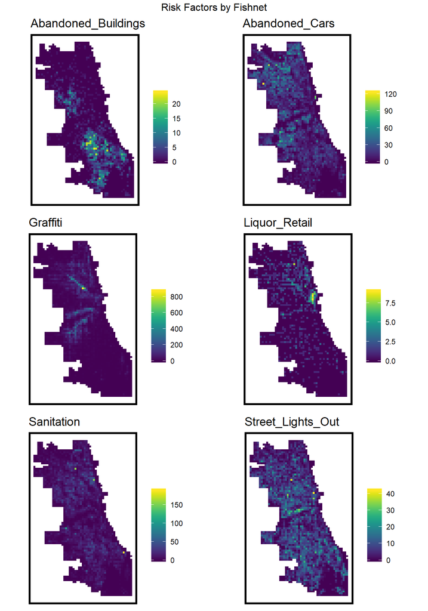

```r
vars_net.long <-
  vars_net %>%
  gather(Variable, value, -geometry, -uniqueID)

vars <- unique(vars_net.long$Variable)
mapList <- list()

for(i in vars){
  mapList[[i]] <-
    ggplot() +
      geom_sf(data = filter(vars_net.long, Variable == i), aes(fill=value), colour=NA) +
      scale_fill_viridis(name="") +
      labs(title=i) +
      mapTheme()}

do.call(grid.arrange,c(mapList, ncol =2, top = "Risk Factors by Fishnet"))
```

## 3.2 Feature engineering - Nearest neighbor features

By counting risk factor events by grid cell, the exposure hypothesizes is tested at a very rigid scale and such a framework opens us up to all sorts of possible MAUP bias. As before, average nearest neighbor distance is likely a better approach for understanding local exposure to risk factors. The function calculates nearest neighbor distance.

```r
nn_function <- function(measureFrom,measureTo,k) {
  measureFrom_Matrix <-
    as.matrix(measureFrom)
  measureTo_Matrix <-
    as.matrix(measureTo)
  nn <-
    get.knnx(measureTo, measureFrom, k)$nn.dist
    output <-
      as.data.frame(nn) %>%
      rownames_to_column(var = "thisPoint") %>%
      gather(points, point_distance, V1:ncol(.)) %>%
      arrange(as.numeric(thisPoint)) %>%
      group_by(thisPoint) %>%
      summarize(pointDistance = mean(point_distance)) %>%
      arrange(as.numeric(thisPoint)) %>%
      dplyr::select(-thisPoint) %>%
      pull()

  return(output)
}
```

Below, average nearest neighbor features are created for the six risk factor variables with *k = 3*. These features are created by converting `vars_net` polygon grid cells to points, then measuring average nearest neighbor distance. Note, the `nn_function` requires both input layers to be points. For demonstration purposes *k* is set to 3, but in a real model, one would want to test many different *k* definitions of scale.

```r
vars_net$Abandoned_Buildings.nn =
    nn_function(st_coordinates(st_centroid(vars_net)), st_coordinates(abandonBuildings), 3)

vars_net$Abandoned_Cars.nn =
    nn_function(st_coordinates(st_centroid(vars_net)), st_coordinates(abandonCars), 3)

vars_net$Graffiti.nn =
    nn_function(st_coordinates(st_centroid(vars_net)), st_coordinates(graffiti), 3)

vars_net$Liquor_Retail.nn =
    nn_function(st_coordinates(st_centroid(vars_net)), st_coordinates(liquorRetail), 3)

vars_net$Street_Lights_Out.nn =
    nn_function(st_coordinates(st_centroid(vars_net)), st_coordinates(streetLightsOut), 3)

vars_net$Sanitation.nn =
    nn_function(st_coordinates(st_centroid(vars_net)), st_coordinates(sanitation), 3)
```

The nearest neighbor features are then plotted below. Note the use of `select` and `ends_with` to map only the newly generated nearest neighor features. Clearly, this approach considers expsosure at a different scale then simply counting up risk factor events by grid cell.

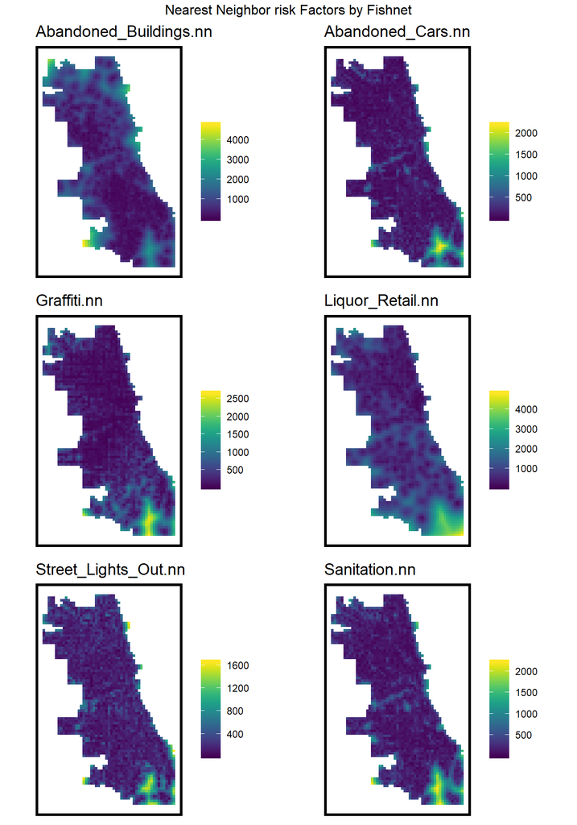

```r
vars_net.long.nn <-
  vars_net %>%
  dplyr::select(ends_with(".nn")) %>%
  gather(Variable, value, -geometry, -uniqueID)

vars <- unique(vars_net.long.nn$Variable)
mapList <- list()

for(i in vars){
  mapList[[i]] <-
    ggplot() +
      geom_sf(data = filter(vars_net.long.nn, Variable == i), aes(fill=value), colour=NA) +
      scale_fill_viridis(name="") +
      labs(title=i) +
      mapTheme()}

do.call(grid.arrange,c(mapList, ncol =2, top = "Nearest Neighbor risk Factors by Fishnet"))
```

## 3.3 Feature Engineering - Measure distance to one point

It also may be reasonable to measure distance to a single point, like the centroid for the Loop neighbor - Chicago’s Central Business District. This is done with `st_distance`.

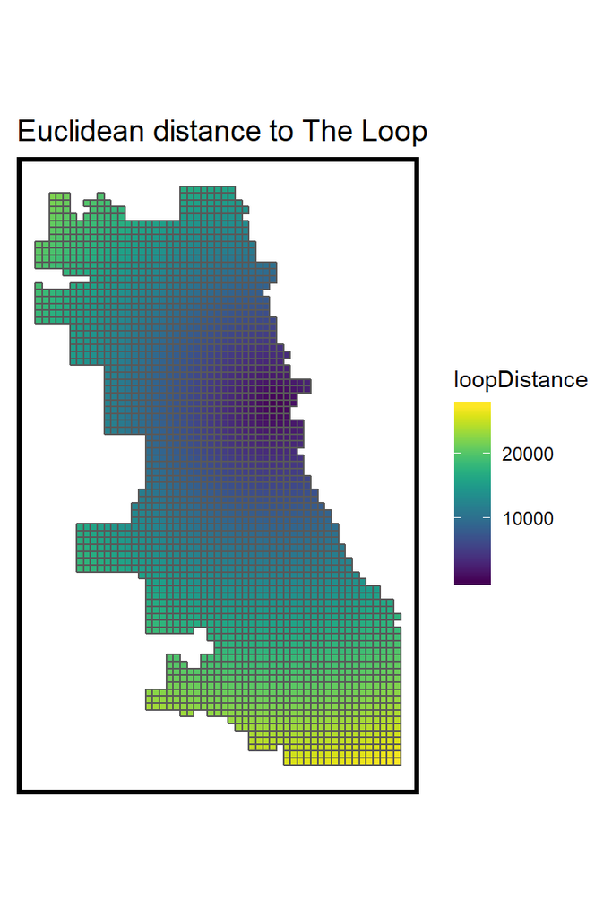

```r
loopPoint <-
  neighborhoods %>%
  filter(name == "Loop") %>%
  st_centroid()

vars_net$loopDistance =
  st_distance(st_centroid(vars_net),loopPoint) %>%
  as.numeric()

ggplot() +
  geom_sf(data=vars_net, aes(fill=loopDistance)) +
  scale_fill_viridis() +
  labs(title="Euclidean distance to The Loop") +
  mapTheme()
```

## 3.4 Feature Engineering - Create the `final_net`

Next, the `crime_net` and `vars_net` layers are joined into a final dataset, `final_net`. Note that`vars_net` is converted to a data frame with `st_set_geometry`, which avoids problems related to duplicate `geometry` fields.

```r
final_net <-
  left_join(crime_net, st_set_geometry(vars_net, NULL), by="uniqueID")
```

Finally, neighborhood `name` and `policeDistrict` is spatially joined to the `final_net` using grid cell centroids. Note that some grid cell centroids do not fall into a neighborhood, returning `NA`, which is then removed with `na.omit`. Other neighborhoods are so small, they are only represented by one grid cell.

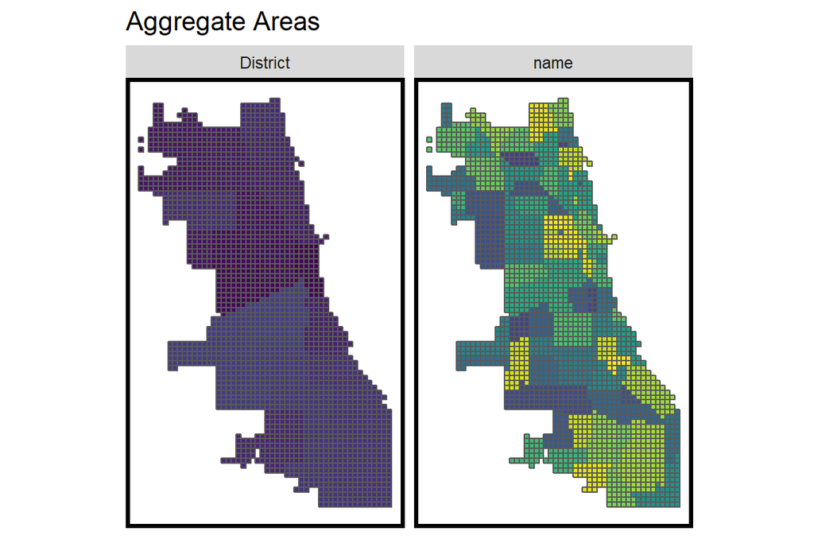

```r
final_net <-
  st_centroid(final_net) %>%
    st_join(., dplyr::select(neighborhoods, name)) %>%
    st_join(., dplyr::select(policeDistricts, District)) %>%
      st_set_geometry(NULL) %>%
      left_join(dplyr::select(final_net, geometry, uniqueID)) %>%
      st_sf() %>%
  na.omit()

dplyr::select(final_net, name, District) %>%
  gather(Variable, Value, -geometry) %>%
    ggplot() +
      geom_sf(aes(fill = Value)) +
      facet_wrap(~Variable) +
      scale_fill_viridis(discrete = TRUE) +
      labs(title = "Aggregate Areas") +
      mapTheme() + theme(legend.position = "none")
```

# 4.1 Exploring the spatial structure of burglary

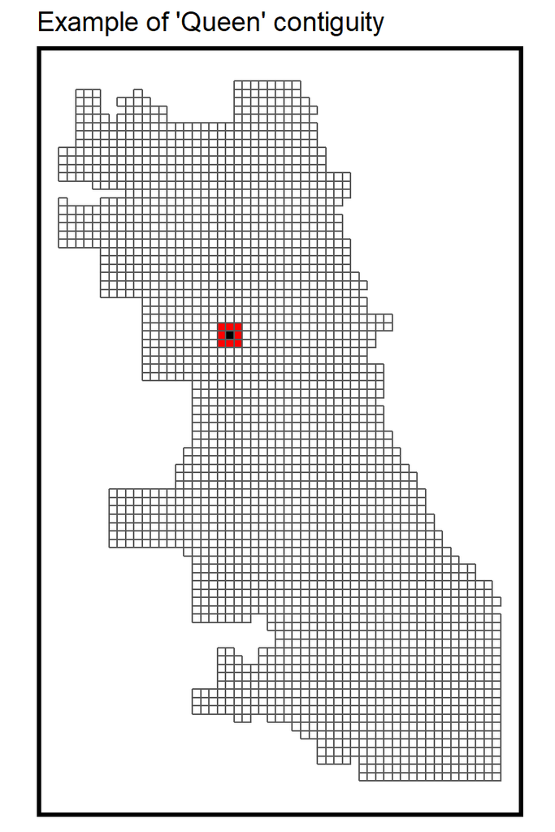

```r
final_net.nb <- poly2nb(final_net, queen=TRUE)
final_net.weights <- nb2listw(final_net.nb, style="W", zero.policy=TRUE)

ggplot() +
  geom_sf(data = slice(final_net, 1483, 1484,1485, 1456, 1458,1429,1430,1431), fill = "red") +
  geom_sf(data = slice(final_net, 1457), fill = "black") +
  geom_sf(data = crime_net, fill = NA) +
  labs(title = "Example of 'Queen' contiguity") +
  mapTheme()
```

The purpose of the visualization below is describe the spatial process of interest. `final_net.localMorans` is created by `cbind`ing together `final_net` with the results of a `localmoran` test. The inputs to the test including the outcome of interest, `countBurglaries` and the spatial weights matrix. Several useful test statistics are output including *I*, the p-value and `Significiant_Hotspots`, defined as those grid cells with p-values <= 0.05. The data frame is then converted to long form for mapping.

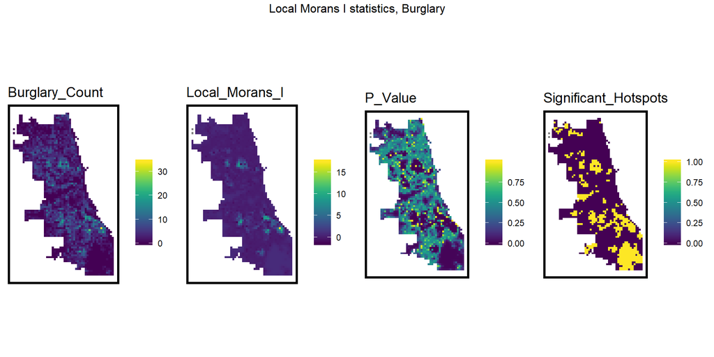

```r
final_net.localMorans <-
  cbind(
    as.data.frame(localmoran(final_net$countBurglaries, final_net.weights)),
    as.data.frame(final_net, NULL)) %>%
    st_sf() %>%
    dplyr::select(Burglary_Count = countBurglaries,
                  Local_Morans_I = Ii,
                  P_Value = `Pr(z > 0)`) %>%
    mutate(Significant_Hotspots = ifelse(P_Value <= 0.05, 1, 0)) %>%
    gather(Variable, Value, -geometry)

vars <- unique(final_net.localMorans$Variable)
varList <- list()

for(i in vars){
  varList[[i]] <-
    ggplot() +
      geom_sf(data = filter(final_net.localMorans, Variable == i), aes(fill = Value), colour=NA) +
      scale_fill_viridis(name="") +
      labs(title=i) +
      mapTheme()}

do.call(grid.arrange,c(varList, ncol = 4, top = "Local Morans I statistics, Burglary"))
```

A generalizable model is one which will have to predict equally as well in the hotspots as the coldspots. In other words, a model fit only to the coldspots, will underfit to the hotspots. A model fit only to the hotspots will overfit the coldspots. As we saw with home prices, our hypothesis is that these spatial structure features will lead to more accurate and more generalizable predictions. Let’s see how new features can be engineered to best capture the local spatial structure.

Below, Local Moran’s I is calculated in the `final_net`. A dummy variable is created with `ifelse` to denote that a significant cluster, `isSig`, is defined as one with a p-value <= 0.0000001. In this instance, the goal is to find clusters that are far more significant than 0.05. Then, `burglary.isSig.dist` measures distance from each grid cell to its nearest significant cluster. The result is mapped in the figure below. This distance feature makes some significant assumptions about the local spatial process - namely that burglaries dissipate in a linear fashion from burglary ‘hotspots’ outward. The analyst could consider a whole host of way to model this trend with different significance thresholds, significance nearest neighbors and beyond.

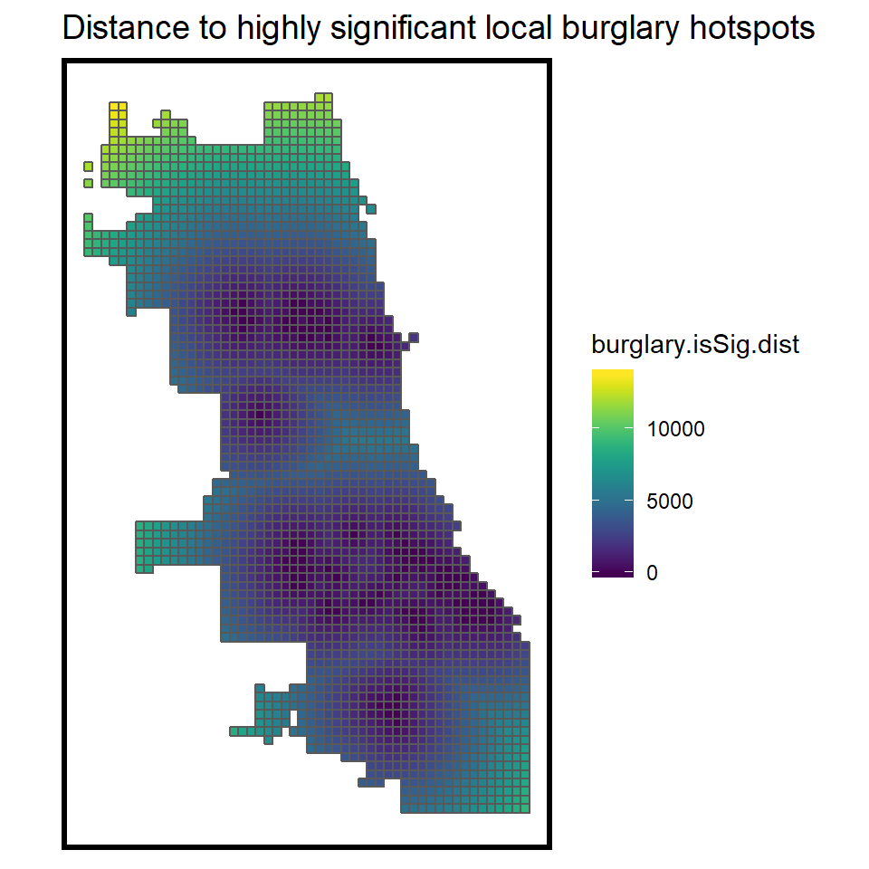

```r
final_net <-
  final_net %>%
  mutate(burglary.isSig = ifelse(localmoran(final_net$countBurglaries,
                                            final_net.weights)[,5] <= 0.0000001, 1, 0)) %>%
  mutate(burglary.isSig.dist = nn_function(st_coordinates(st_centroid(final_net)),
                                           st_coordinates(st_centroid(
                                             filter(final_net, burglary.isSig == 1))), 1 ))

ggplot() +
  geom_sf(data = final_net, aes(fill = burglary.isSig.dist)) +
  scale_fill_viridis() +
  labs(title = "Distance to highly significant local burglary hotspots") +
  mapTheme()
```

## 4.1 Correlation tests

The code block below creates a small multiple scatterplot of `countBurglaries` as a function of the risk factors. `correlation.long` converts `final_net` to long form. `correlation.cor` does the same, but then groups by `Variable` and calculates the Pearson R correlation which is then be visualized directly on the plot below. It’s clear that the count and nearest neighbor features tell similar stories with different directions of association. As the count of `Abandoned_Buildings` increases in a grid cell, so does the number of burglaries. As the distance from burglaries decreases so does the count of `Abandoned_Buildings`.

Both features for a given risk factor cannot be included in the model because of co-linearity. This plot and the correlation coefficients help us understand which type of feature for a given risk factor should be included.

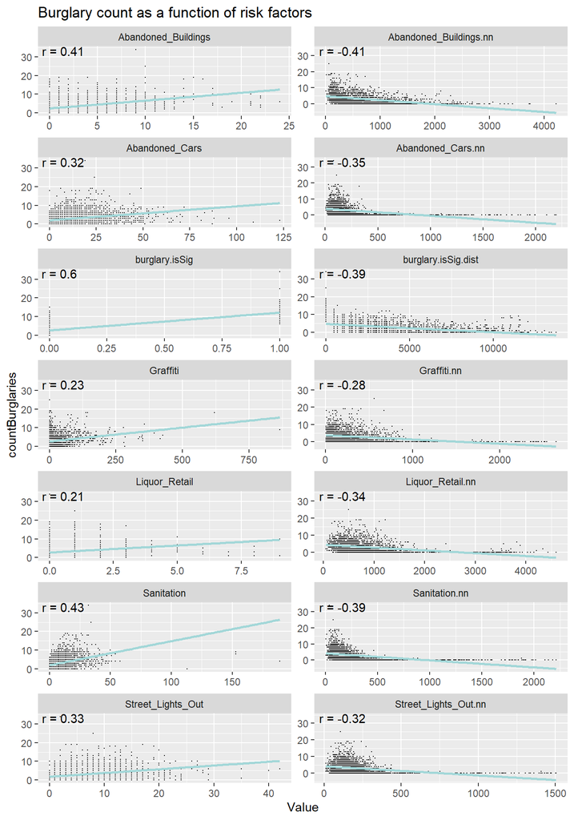

```r
correlation.long <-
  st_set_geometry(final_net, NULL) %>%
    dplyr::select(-uniqueID, -cvID, -loopDistance, -name, -District) %>%
    gather(Variable, Value, -countBurglaries)

correlation.cor <-
  correlation.long %>%
    group_by(Variable) %>%
    summarize(correlation = cor(Value, countBurglaries, use = "complete.obs"))

ggplot(correlation.long, aes(Value, countBurglaries)) +
  geom_point(size = 0.1) +
  geom_text(data = correlation.cor, aes(label = paste("r =", round(correlation, 2))),
            x=-Inf, y=Inf, vjust = 1, hjust = -.1) +
  geom_smooth(method = "lm", se = FALSE, colour = "#a2d7d8") +
  facet_wrap(~Variable, ncol = 2, scales = "free") +
  labs(title = "Burglary count as a function of risk factors")
```

# 5.1 Poisson Regression

Take a look at the distribution of `countBurglaries` in the histogram before. Unlike home prices which were normally distributed (like a bell curve), the distribution burglaries is far more skewed. This should be intuitive, given that crime is a relatively rare event. When data is distributed in this way, an OLS regression is inappropriate. In this section, we learn and demonstrate Poisson Regression, uniquely suited to modeling an count outcome like `countBurglaries`.

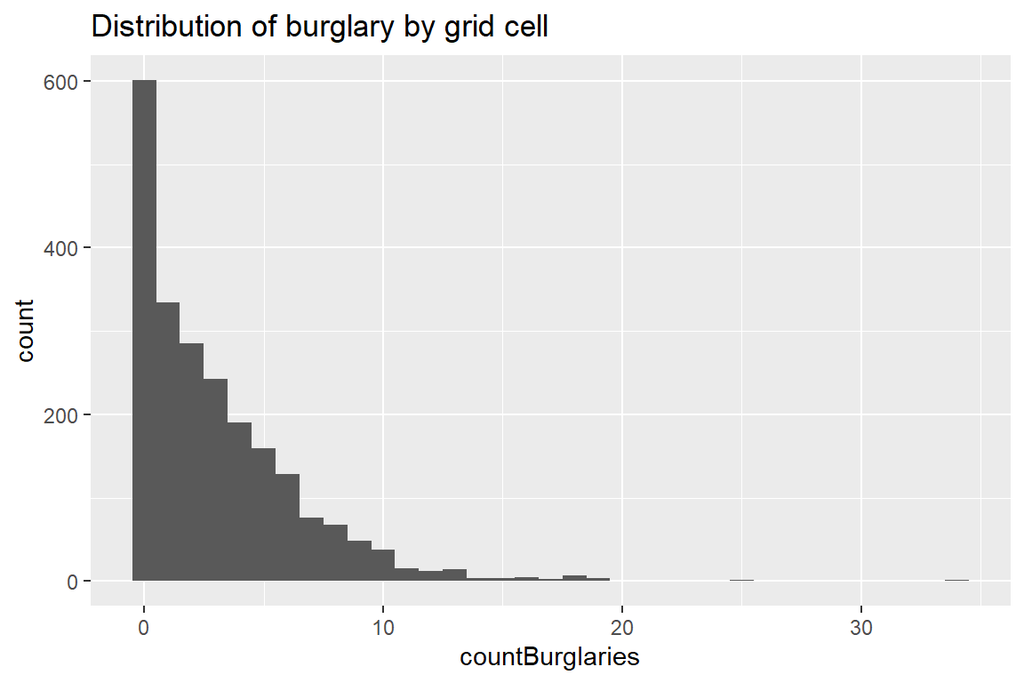

```r
ggplot(final_net, aes(countBurglaries)) +
  geom_histogram(binwidth = 1) +
  labs(title = "Distribution of burglary by grid cell")
```

The choice of algorithm, poisson or otherwise, is a function of the data and the use case. We could recode the burglary data to a binomial outcome suited for logistic regression, where `0` means no burglaries in a grid cell and `1` means more than 0 burglaries. This would give a prediction intepreted as the ‘probability of a burglary being committed here’. 73% of grid cells have at least 1 burglary, which would render most areas as having a high probability. Regressing on a count outcome is useful because it predicts a more continuous quantity of risk.

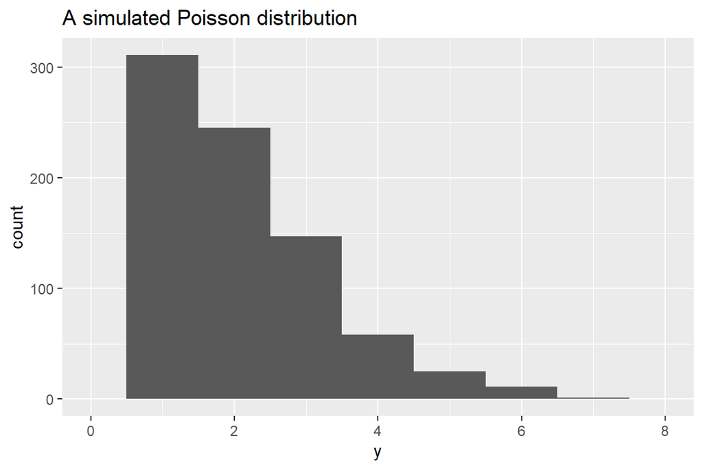

## 5.2 Cross-validated poisson Regression

Unlike previous chapters, we are not going to split the `final_net` into training and test sets. Moving directly to cross-validation is a much more useful approach to guaging generalizability in these models. House prices partially rely on aspatial features like number of bedrooms, but geospatial risk models are purely spatial in nature. This means that we can perform spatial cross-validation to guage generalizability

A well generalized crime predictive model must predict equally as well in all communities and a geospatial model that predicts equally well in all neighborhoods is one which can learn crime risk patterns that apply at both Citywide and local spatial scales. The local scale is particularly difficult to model, because the burglarly experience in one place may only be unique to that one place. The best way to ensure that the model has learned both the global and local dynamics, is to hold out one local area, train the model on the remaining *n - 1* areas and then predict for the held out area. We refer to this approach as Leave-one-group-out cross-validation (LOGO-CV).

Three `final_net` fields can be used for cross-validation. A random generated `cvID` associated with each grid cell can be used for random k-fold cross-validation. Neighborhood `name` and police `District` can be used for spatial cross-validation.

Goodness of fit metrics will be generated for both random k-fold and LOGO cross validations for two different specifications (4 total regressions). The first includes `Just Risk Factors` features and are listed in `reg.vars` below. The second includes both the risk factors plus the `Spatial Structure` features created in x.4.1. These are listed in `reg.ss.vars`.

```r
reg.vars <- c("Abandoned_Buildings.nn", "Abandoned_Cars.nn", "Graffiti.nn",
              "Liquor_Retail.nn", "Street_Lights_Out.nn", "Sanitation.nn", "loopDistance")

reg.ss.vars <- c("Abandoned_Buildings.nn", "Abandoned_Cars.nn", "Graffiti.nn", "Liquor_Retail.nn",
                 "Street_Lights_Out.nn", "Sanitation.nn", "loopDistance",
                 "burglary.isSig", "burglary.isSig.dist")
```

The `crossValidate` function below is a very stripped down version of Caret’s `train` function. It takes an input `dataset`; a cross-validation `id`; a `dependentVariable` and a list of independent variables, `indVariables`. `cvID_list` is a list of unique `id`s which could be numbers or neighborhood `name`, for instance. For a given iteration, For given neighborhood `name`, the function assigns each grid cell *not* in that neighborhood to the training set, `fold.train`, and each cell *in* that neighborhood to the test set, `fold.test`. A model is trained from the former and used to predict on the latter. The process is repeated until each neighborhood has a turn acting as a hold out. The output is a simple features data frame with a `Prediction` for each grid cell. **For now**, the `countBurglaries` variable is hardwired into the function, which you will **have to change** when you do your homework.

```r
crossValidate <- function(dataset, id, dependentVariable, indVariables) {

allPredictions <- data.frame()
cvID_list <- unique(dataset[[id]])

for (i in cvID_list) {

  thisFold <- i
  cat("This hold out fold is", thisFold, "\n")

  fold.train <- filter(dataset, dataset[[id]] != thisFold) %>% as.data.frame() %>%
                dplyr::select(id, geometry, indVariables, dependentVariable)
  fold.test  <- filter(dataset, dataset[[id]] == thisFold) %>% as.data.frame() %>%
                dplyr::select(id, geometry, indVariables, dependentVariable)

  regression <-
    glm(countBurglaries ~ ., family = "poisson",
      data = fold.train %>%
      dplyr::select(-geometry, -id))

  thisPrediction <-
    mutate(fold.test, Prediction = predict(regression, fold.test, type = "response"))

  allPredictions <-
    rbind(allPredictions, thisPrediction)

  }
  return(st_sf(allPredictions))
}
```

The code block below runs `crossValidate` to estimate four different regressions that are then compared below. `reg.cv` and `reg.ss.cv` perform random k-fold cross validation using `Just Risk Factors` and the `Spatial Structure` features, respectively. `reg.spatialCV` and `reg.ss.spatialCV` perform LOGO spatial cross validation using the aforementioned two groups of features.

The function makes it easy to swap out different cross-validation group `id`s. k-fold cross validation uses the `cvID`. LOGO uses the neighborhood `name`. You may also wish to explore results using the Police `Districts`. Note, in the `select` operation at the end of the LOGO-CV models, the cross validation `id` is standardized to `cvID`.

```r
reg.cv <- crossValidate(
  dataset = final_net,
  id = "cvID",
  dependentVariable = "countBurglaries",
  indVariables = reg.vars) %>%
    dplyr::select(cvID = cvID, countBurglaries, Prediction, geometry)

reg.ss.cv <- crossValidate(
  dataset = final_net,
  id = "cvID",
  dependentVariable = "countBurglaries",
  indVariables = reg.ss.vars) %>%
    dplyr::select(cvID = cvID, countBurglaries, Prediction, geometry)

reg.spatialCV <- crossValidate(
  dataset = final_net,
  id = "name",
  dependentVariable = "countBurglaries",
  indVariables = reg.vars) %>%
    dplyr::select(cvID = name, countBurglaries, Prediction, geometry)

reg.ss.spatialCV <- crossValidate(
  dataset = final_net,
  id = "name",
  dependentVariable = "countBurglaries",
  indVariables = reg.ss.vars) %>%
    dplyr::select(cvID = name, countBurglaries, Prediction, geometry)
```

## 5.2 Accuracy & Generalzability

As we’ve done in previous chapters, mean error and mean absolute error (MAE) can be calculated on predicted and observed crime counts, then compared across models. Because generalizability in these models is arguable more important than accuracy, below, the latter will be evaluated in the context of the former.

The code block below creates `reg.summary`, a simple features data frame that for each `Regression`, includes grid cell measures of `Prediction`, `Error`, the observed `countBurglaries`, the `cvID` and the `geometry`.

```r
reg.summary <-
  rbind(
    mutate(reg.cv,           Error = countBurglaries - Prediction,
                             Regression = "Random k-fold CV: Just Risk Factors"),

    mutate(reg.ss.cv,        Error = countBurglaries - Prediction,
                             Regression = "Random k-fold CV: Spatial Structure"),

    mutate(reg.spatialCV,    Error = countBurglaries - Prediction,
                             Regression = "Spatial LOGO-CV: Just Risk Factors"),

    mutate(reg.ss.spatialCV, Error = countBurglaries - Prediction,
                             Regression = "Spatial LOGO-CV: Spatial Structure")) %>%
    st_sf()
```

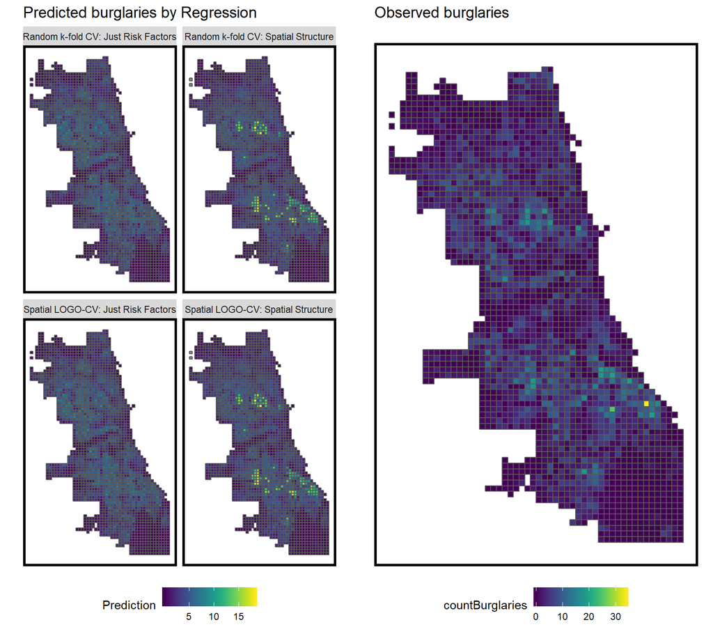

```r
grid.arrange(
  reg.summary %>%
    ggplot() +
      geom_sf(aes(fill = Prediction)) +
      facet_wrap(~Regression) +
      scale_fill_viridis() +
      labs(title = "Predicted burglaries by Regression") +
      mapTheme() + theme(legend.position="bottom"),

  filter(reg.summary, Regression == "Random k-fold CV: Just Risk Factors") %>%
    ggplot() +
      geom_sf(aes(fill = countBurglaries)) +
      scale_fill_viridis() +
      labs(title = "Observed burglaries\n") +
      mapTheme() + theme(legend.position="bottom"), ncol = 2)
```

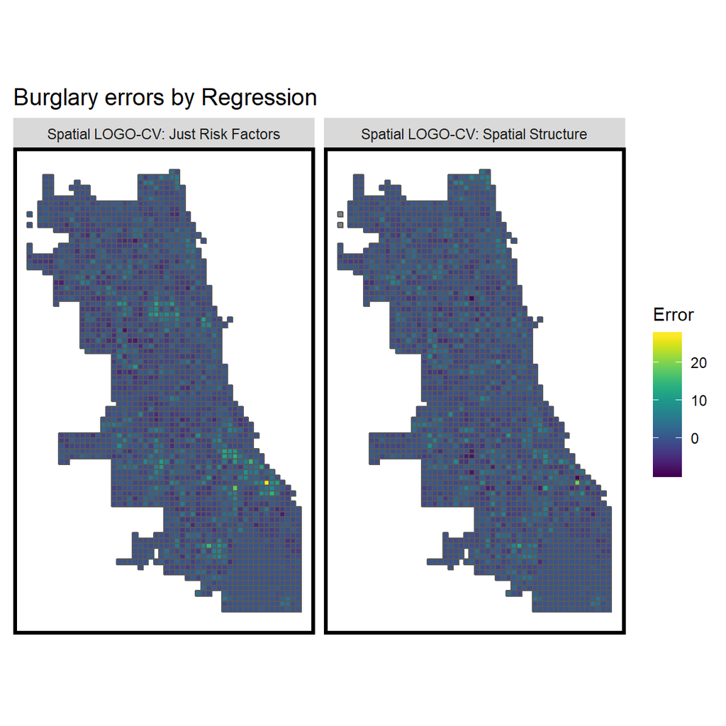

```r
filter(reg.summary, Regression == "Spatial LOGO-CV: Just Risk Factors" |
         Regression == "Spatial LOGO-CV: Spatial Structure") %>%
  ggplot() +
    geom_sf(aes(fill = Error)) +
    facet_wrap(~Regression) +
    scale_fill_viridis() +
    labs(title = "Burglary errors by Regression") +
    mapTheme()
```

Now let’s examine MAE and the standard deviation of MAE across each fold for each regression type. The interpretation is that these models err by roughly 1.5 burglaries, on an absolute basis, on average. For context, the mean `countBurglaries` is 3.0464908. Absolute errors are useful, but given the concern that overpredicting might draw undue attention to minority neighborhoods, it might be helpful in this use case, to look at raw errors.

Another very important takeaway from this table is a reconfirmation that regressions with the spatial structural features are much more accurate and more generalizable. These features are doing a better job predicting the hotspots.

```r
st_set_geometry(reg.summary, NULL) %>%
  group_by(Regression) %>%
  summarize(MAE = round(mean(abs(Prediction - countBurglaries), na.rm = T),2),
            SD_MAE = round(sd(abs(Prediction - countBurglaries), na.rm = T),2)) %>%
  kable(caption = "MAE by regression") %>%
    kable_styling("striped", full_width = F) %>%
    row_spec(2, color = "black", background = "#FDE725FF") %>%
    row_spec(4, color = "black", background = "#FDE725FF")
```

MAE by regression

| Regression | MAE | SD_MAE |
| --- | --- | --- |
| Random k-fold CV: Just Risk Factors | 1.77 | 1.97 |
| Random k-fold CV: Spatial Structure | 1.56 | 1.55 |
| Spatial LOGO-CV: Just Risk Factors | 1.78 | 1.98 |
| Spatial LOGO-CV: Spatial Structure | 1.57 | 1.56 |

The spatial structure features provide marginal improvements in the 1st to the 9th deciles. However, in the highest burglary grid cells, the spatial features improve errors by nearly half. This is expected, given the spatial features are engineered specifically to captuare hotspots.

It’s also interesting to note that it seems all models overpredict in the 1st through 5th deciles, but then underpredict in the 8th through 10th deciles. In other words, we overpredict in low burglary areas and underpredict in high burglary areas. How might this finding effect our use of this algorithm as a police allocation tool?

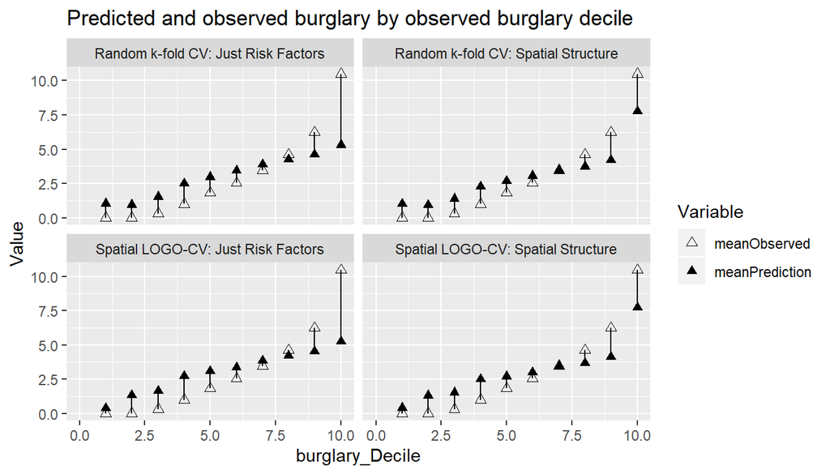

```r
st_set_geometry(reg.summary, NULL) %>%
  group_by(Regression) %>%
    mutate(burglary_Decile = ntile(countBurglaries, 10)) %>%
  group_by(Regression, burglary_Decile) %>%
    summarize(meanObserved = mean(countBurglaries, na.rm=T),
              meanPrediction = mean(Prediction, na.rm=T)) %>%
    gather(Variable, Value, -Regression, -burglary_Decile) %>%
    ggplot(aes(burglary_Decile, Value, shape = Variable)) +
      geom_point(size = 2) + geom_path(aes(group = burglary_Decile), colour = "black") +
      scale_shape_manual(values = c(2, 17)) +
      facet_wrap(~Regression) + xlim(0,10) +
      labs(title = "Predicted and observed burglary by observed burglary decile")
```

## 5.3 Generalizability by neighborhood context

Now we get down to the important question of whether these algorithms can perpetuate racial bias. In x.1.1 we discussed how systematic over-policing of certain communities may lead to a reporting or selection bias, and if left unaccounted for, this variation will fall into the error term of the regression. If this reporting bias falls along racial lines, then the resulting predictions may exasperate racist policing practices and have a disparate impact on communities of color.

This proposition is tested in this section. Below `tidycensus` is used to pull race data by Census Tract. `percentWhite` is calculated and tracts are split into two groups, `Majority_White` and `Majority_Non_White`. A spatial subset is used to get tracts within the study area.

```r
tracts17 <-
  get_acs(geography = "tract", variables = c("B01001_001E","B01001A_001E"),
          year = 2017, state=17, county=031, geometry=T) %>%
  st_transform(102271)  %>%
  dplyr::select(variable, estimate, GEOID) %>%
  spread(variable, estimate) %>%
  rename(TotalPop = B01001_001,
         NumberWhites = B01001A_001) %>%
  mutate(percentWhite = NumberWhites / TotalPop,
         raceContext = ifelse(percentWhite > .5, "Majority_White", "Majority_Non_White")) %>%
  .[neighborhoods,]
```

Like Boston, Chicago is a very segregated City, as the map below shows.

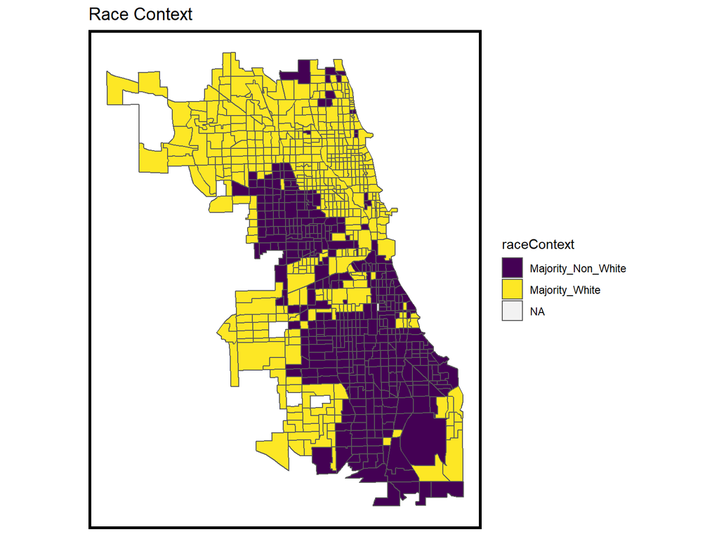

```r
ggplot() +
  geom_sf(data = tracts17, aes(fill = raceContext)) +
  scale_fill_viridis(discrete = TRUE) +
  labs(title = "Race Context", name="Race Context") +
  mapTheme()
```

Below, `final_reg` is output to include `Error` for just the two spatially cross-validated regressions. A new `uniqueID` is also created to facilitate the joining of `final_reg` to `tracts17`. Joining grid cell and tract polygons would be messy. Instead, the grid cells in `final_reg` are converted to centroid points which are then joined back to the grid cells polygons via (a non-spatial) `left_join`.

Not surprisingly however, the model with the spatial features not only reports lower errors but a much lower difference in errors across neighborhood context. Next, let’s contrast this finding with this algorithm’s overall usefulness as a police resouce allocation tool.

```r
final_reg <-
  filter(reg.summary, Regression == "Spatial LOGO-CV: Spatial Structure" |
                      Regression == "Spatial LOGO-CV: Just Risk Factors") %>%
  mutate(uniqueID = rownames(.))

final_reg.tracts <-
  st_join(st_centroid(final_reg), tracts17) %>%
    st_set_geometry(NULL) %>%
    left_join(dplyr::select(final_reg, uniqueID)) %>%
    st_sf() %>%
    na.omit()

st_set_geometry(final_reg.tracts, NULL) %>%
  group_by(Regression, raceContext) %>%
  summarize(mean.Error = mean(Error, na.rm = T)) %>%
  spread(raceContext, mean.Error) %>%
  kable(caption = "Mean Error by neighborhood racial context") %>%
    kable_styling("striped", full_width = F)
```

Mean Error by neighborhood racial context

| Regression | Majority_Non_White | Majority_White |
| --- | --- | --- |
| Spatial LOGO-CV: Just Risk Factors | 0.1351682 | -0.1382732 |
| Spatial LOGO-CV: Spatial Structure | 0.0603132 | -0.0490975 |

## 6.1 Does this model allocate better than traditional crime hotspots?

Kernel Density works by centering a smooth kernel or curve over each point, such that the kernel is at its highest directly over the point and the lowest at the range of a circular search radius. The value of the kernel density in a particular place is the sum of all the kernels that underlie it. Thus, areas that have many points in close proximity will have relative densities. The key scale assumption in a kernel density is the specification of a global search radius. Below, kernel density built from three different search radii are shown.

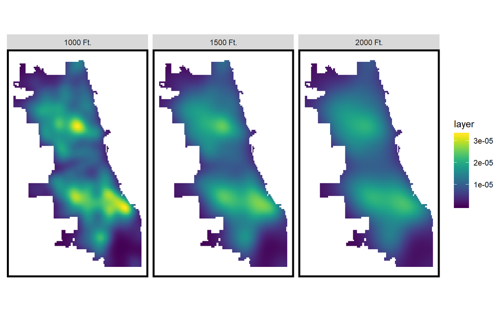

```r
library(raster)
burg_ppp <- as.ppp(st_coordinates(burglaries), W = st_bbox(final_net))
burg_KD.1000 <- spatstat::density.ppp(burg_ppp, 1000)
burg_KD.1500 <- spatstat::density.ppp(burg_ppp, 1500)
burg_KD.2000 <- spatstat::density.ppp(burg_ppp, 2000)
burg_KD.df <- rbind(
  mutate(data.frame(rasterToPoints(mask(raster(burg_KD.1000), as(neighborhoods, 'Spatial')))), Legend = "1000 Ft."),
  mutate(data.frame(rasterToPoints(mask(raster(burg_KD.1500), as(neighborhoods, 'Spatial')))), Legend = "1500 Ft."),
  mutate(data.frame(rasterToPoints(mask(raster(burg_KD.2000), as(neighborhoods, 'Spatial')))), Legend = "2000 Ft."))

burg_KD.df$Legend <- factor(burg_KD.df$Legend, levels = c("1000 Ft.", "1500 Ft.", "2000 Ft."))

ggplot(data=burg_KD.df, aes(x=x, y=y)) +
  geom_raster(aes(fill=layer)) +
  facet_wrap(~Legend) +
  coord_sf(crs=st_crs(final_net)) +
  scale_fill_viridis() +
  mapTheme()
```

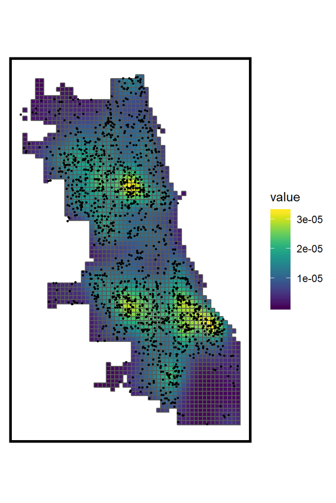

```r
burg_ppp <- as.ppp(st_coordinates(burglaries), W = st_bbox(final_net))
burg_KD <- spatstat::density.ppp(burg_ppp, 1000)

as.data.frame(burg_KD) %>%
  st_as_sf(coords = c("x", "y"), crs = st_crs(final_net)) %>%
  aggregate(., final_net, mean) %>%
   ggplot() +
     geom_sf(aes(fill=value)) +
     geom_sf(data = sample_n(burglaries, 1500), size = .5) +
     scale_fill_viridis() +
     mapTheme()
```

Next, a goodness of fit indicator is created to illustrate whether the risk predictions capture more of the *observed burglaries* relative to the kernel density. If the predictions do capture more observed burglaries, then the risk predictive model provides more robust targeting tool for allocating police resources. Here are the steps.

1. Compute the kernel density; and `aggregate` to the fishnet.
2. Scale the kernel density to run from 1-100 and then reclassify those values into 5 risk categories.
3. Join to that, the count of burglaries for each grid cell.
4. Repeat for the risk predictions.
5. Count the rate of test set points by model type and risk category. Map and plot accordingly.

Below, the needed components for kernel density are computed.

```r
# Compute kernel density
burg_ppp <- as.ppp(st_coordinates(burglaries), W = st_bbox(final_net))
burg_KD <- spatstat::density.ppp(burg_ppp, 1000)
# Convert kernel density to grid cells taking the mean
burg_KDE_sf <- as.data.frame(burg_KD) %>%
  st_as_sf(coords = c("x", "y"), crs = st_crs(final_net)) %>%
  aggregate(., final_net, mean) %>%
#Mutate the Risk_Category field as defined below.
  mutate(label = "Kernel Density",
         Risk_Category = ntile(value, 100),
         Risk_Category = case_when(
           Risk_Category >= 90 ~ "90% to 100%",
           Risk_Category >= 70 & Risk_Category <= 89 ~ "70% to 89%",
           Risk_Category >= 50 & Risk_Category <= 69 ~ "50% to 69%",
           Risk_Category >= 30 & Risk_Category <= 49 ~ "30% to 49%",
           Risk_Category >= 1 & Risk_Category <= 29 ~ "1% to 29%")) %>%
#Bind to a layer where test set crime counts are spatially joined to the fisnnet.
  bind_cols(
    aggregate(
      dplyr::select(burglaries) %>% mutate(burgCount = 1), ., length) %>%
    mutate(burgCount = replace_na(burgCount, 0))) %>%
#Select the fields we need
  dplyr::select(label, Risk_Category, burgCount)

head(burg_KDE_sf)
```

```
## Simple feature collection with 6 features and 3 fields
## geometry type:  POLYGON
## dimension:      XY
## bbox:           xmin: 359664.1 ymin: 552875.4 xmax: 362664.1 ymax: 553375.4
## epsg (SRID):    102271
## proj4string:    +proj=tmerc +lat_0=36.66666666666666 +lon_0=-88.33333333333333 +k=0.9999749999999999 +x_0=300000 +y_0=0 +ellps=GRS80 +towgs84=0,0,0,0,0,0,0 +units=m +no_defs
##            label Risk_Category burgCount                       geometry
## 1 Kernel Density     1% to 29%         2 POLYGON ((359664.1 552875.4...
## 2 Kernel Density     1% to 29%         0 POLYGON ((360164.1 552875.4...
## 3 Kernel Density     1% to 29%         0 POLYGON ((360664.1 552875.4...
## 4 Kernel Density     1% to 29%         0 POLYGON ((361164.1 552875.4...
## 5 Kernel Density     1% to 29%         0 POLYGON ((361664.1 552875.4...
## 6 Kernel Density     1% to 29%         0 POLYGON ((362164.1 552875.4...
```

Now, to repeat for the risk predictions. Note the prediction from the LOGO-CV with the spatial features is being used here.

```r
burg_risk_sf <-
  filter(final_reg, Regression == "Spatial LOGO-CV: Spatial Structure") %>%
  mutate(label = "Risk Predictions",
         Risk_Category = ntile(Prediction, 100),
         Risk_Category = case_when(
           Risk_Category >= 90 ~ "90% to 100%",
           Risk_Category >= 70 & Risk_Category <= 89 ~ "70% to 89%",
           Risk_Category >= 50 & Risk_Category <= 69 ~ "50% to 69%",
           Risk_Category >= 30 & Risk_Category <= 49 ~ "30% to 49%",
           Risk_Category >= 1 & Risk_Category <= 29 ~ "1% to 29%")) %>%
  bind_cols(
    aggregate(
      dplyr::select(burglaries) %>% mutate(burgCount = 1), ., length) %>%
      mutate(burgCount = replace_na(burgCount, 0))) %>%
  dplyr::select(label,Risk_Category, burgCount)
```

For each grid cell and model type (density vs. risk prediction), there is now an associated risk category and observed burglary count. Below a map is generated of the risk categories for both model types with test set points overlayed. A strongly fit model should show that the highest risk category is uniquely targeted to places with a high density of burglary points.

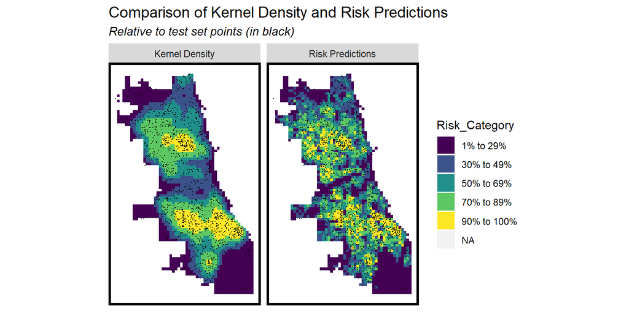

```r
rbind(burg_KDE_sf, burg_risk_sf) %>%
  gather(Variable, Value, -label, -Risk_Category, -geometry) %>%
  ggplot() +
    geom_sf(aes(fill = Risk_Category), colour = NA) +
    geom_sf(data = sample_n(burglaries, 1500), size = .1, colour = "black") +
    facet_wrap(~label, ) +
    scale_fill_viridis(discrete = TRUE) +
    labs(title="Comparison of Kernel Density and Risk Predictions",
         subtitle="Relative to test set points (in black)") +
    mapTheme()
```

Finally, the rate of burglary points by risk category and model type is calculated and plotted. What we would hope to see is that the risk predictions capture a greater share of observed burglary events *in the highest risk category* relative to the kernel density. The very simple model created here narrowly edges out the kernel density in the highest risk category.

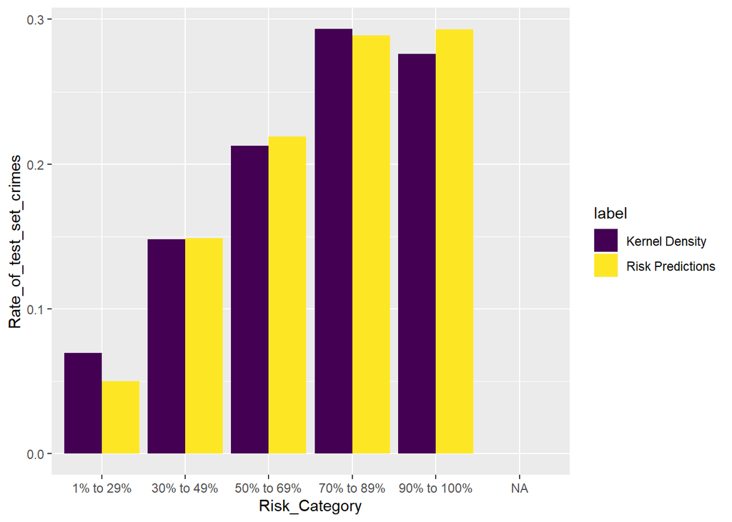

```r
rbind(burg_KDE_sf, burg_risk_sf) %>%
  st_set_geometry(NULL) %>%
  gather(Variable, Value, -label, -Risk_Category) %>%
  group_by(label, Risk_Category) %>%
  summarize(countBurglaries = sum(Value)) %>%
  ungroup() %>%
  group_by(label) %>%
  mutate(Rate_of_test_set_crimes = countBurglaries / sum(countBurglaries)) %>%
    ggplot(aes(Risk_Category,Rate_of_test_set_crimes)) +
      geom_bar(aes(fill=label), position="dodge", stat="identity") +
      scale_fill_viridis(discrete = TRUE)
```

# 6.1 Conclusion

In this chapter, a geospatial risk prediction model was developed to borrow the burglary experience in places burglary has been observed, and test whether that experience generalizes to places where the risk is ‘latent’. Spatial cross-validation was introduced to test generalizability. It is easily the most constrained generalizability test employed thus far. We also learned a host of new spatial structure variables that successfully predicted the local burglary hot spots.

Evaluating the usefulness of a geospatial risk prediction algorithm in a resource allocation context is perhaps more difficult then any other goodness of fit concept covered in this book. If identifying latent risk is the goal (areas at risk for crime despite none being reported), then accuracy becomes less important than generalizability. A useful model then is one that is 1) more accurate than the current decision making process and 2) equally as such for areas across the City.

Burglary was chosen as the outcome of interest because we assume that it is reported with less bias compared to other crimes, like drug crime. Reporting bias could come from victims (un)willingness to call the police, or from police themselves systematically over-policing certain communities. The issue with reporting bias is that it feeds broader concerns over selection bias. It may be that criminals are selecting into areas with certain risk factors or that reporters of crime exhibit some unobserved selection criteria on which crimes to report.

There are other crimes, and other geographic events that may exhibit more or less selection bias. Many cities are collecting 311 data on grafitti. It could be that grafitti is only happening where it’s actually being reported, or that would-be reporters selectively choose where to report grafitti based on community social norms. Conversely, it’s harder to argue that a reporting or selection bias exists for building fires. It’s hard to consider an example where a building fire isn’t reported to a fire department.

Predictive policing is likely the most established machine learning use case in the public sector. Again, this is likely because of the high costs associated with crime and the need for police departments to engage in operational planning. Many of the more robust predictive policing solutions return not only placed-based predictions but time/space predictions. The model described here is easily extendable to time/space with the inclusion of time interval (15, 30, 60 minutes etc.) fixed effects. In the next chapter, we will focus on these time/space effects considering generalizability across both.

One final thought for you to consider. Let’s imagine for a moment that we could predict with 100% certainty where and when crime will occur. How would you effectively deploy such an algorithm into patrol cars? Is it reasonable to assume that your average police officer wants to learn predictive modeling or even understand it’s motivations? Is reasonable to assume that an officer, who relies everyday on his or her accured experience, would ignore their intuition in favor of a notification that pops up on an tablet in their cruiser?

This book is heavily focused on analytics, but deploying those analytics to help someone make a ‘better’ decision is equally as important. The more entrenched the decision-making process, the harder it may be to change. This is where dashboarding, user interface design and user experience design come in to play. The algorithm is only step 1. The more effectively one can design an interface that compliments, not replaces a user’s lived experience, the easier it will be to get stakeholder buy-in.

# 7.1 Homework Deliverables:

Your job is to build a version of this model **for a different outcome that likely suffers from more selection bias than burglary**. You will download a different outcome and at least **two** more features from the Chicago Open Data site.

Your final deliverable should be **in markdown** form **with codeblocks**. Please provide the following materials with **brief annotations** (please don’t forget this). Please include:

1. A map of your outcome of interest in point form, with some description of what, when and why you think selection bias may be an issue in your model.
2. A map of your outcome joined to the fishnet.
3. A small multiple map of your risk factors in the fishnet (counts, distance and/or other feature engineering approaches.
4. Local Moran’s I related small multiple map of your outcome (see 4.1)
5. A small multiple scatterplot with correlations.
6. A histogram of your dependent variable.
7. A small multiple map of model errors by random k-fold and spatial cross validation.
8. A table of MAE and standard deviation MAE by regression.
9. A table of raw errors by race context for a random k-fold vs. spatial cross validation regression.
10. The map comparing kernel density to risk predictions.
11. The bar plot making this comparison.
12. Two paragraphs on why or why not you would recommend your algorithm be put into production.

FIN